# Sixth Week: Linear Models

House price prediction

Ali Mohammad Faraji

2018-04-13 01:05:35

```r
library(highcharter)
library(dplyr)
library(Hmisc)
library(psych)
library(tidyr)
library(olsrr)
library(DAAG)
dic_var = read.delim('dictionnaire_variables.csv',sep = ";")
dic_nvx = read.csv("dictionnaire_niveaux.csv") %>% select(1:3)
colnames(dic_nvx) <- c("variable", "label", "Type")
#View(dic_nvx)
house = read.csv("train.csv")
#View(house)
```

```r
cor_house <- cor(house[sapply(house, is.numeric)], use = "complete.obs")
print(cor_house)
```

```
##                          Id   MSSubClass   LotFrontage      LotArea
## Id             1.0000000000  0.021937479 -0.0132885700 -0.040711142
## MSSubClass     0.0219374785  1.000000000 -0.3869395732 -0.198095532
## LotFrontage   -0.0132885700 -0.386939573  1.0000000000  0.421184102
## LotArea       -0.0407111421 -0.198095532  0.4211841021  1.000000000
## OverallQual   -0.0582692304  0.029521865  0.2413223161  0.167524794
## OverallCond    0.0043866408 -0.087859316 -0.0463116489 -0.034347948
## YearBuilt     -0.0208620907  0.025799678  0.1097255707  0.029205413
## YearRemodAdd  -0.0276643035  0.006645194  0.0864139680  0.026847846
## MasVnrArea    -0.0734716818  0.040239997  0.1899685917  0.106115431
## BsmtFinSF1    -0.0137506789 -0.070388692  0.2413522339  0.230441380
## BsmtFinSF2     0.0125436047 -0.075439002  0.0493053240  0.138233605
## BsmtUnfSF     -0.0129851567 -0.145582343  0.1153058755  0.011288124
## TotalBsmtSF   -0.0231289420 -0.247781211  0.3876195129  0.302553906
## X1stFlrSF     -0.0080455234 -0.252248866  0.4510850287  0.329678689
## X2ndFlrSF     -0.0023457170  0.319327639  0.0750038007  0.074611842
## LowQualFinSF  -0.0399333771  0.024703650  0.0111480855  0.020039426
## GrLivArea     -0.0110683576  0.083365382  0.3963060214  0.307163514
## BsmtFullBath   0.0261125979 -0.014681299  0.1180881480  0.179051563
## BsmtHalfBath  -0.0267735790  0.012309569  0.0004335725 -0.014281611
## FullBath       0.0072200531  0.131278047  0.1857853092  0.129073367
## HalfBath      -0.0104087038  0.203970613  0.0456783485  0.045183485
## BedroomAbvGr   0.0398314240 -0.032971146  0.2704038861  0.137268663
## KitchenAbvGr   0.0259125317  0.266012356 -0.0035464716 -0.018941546
## TotRmsAbvGrd   0.0200115088  0.047209430  0.3484211056  0.237917977
## Fireplaces    -0.0182727886 -0.031122227  0.2603208280  0.255754683
## GarageYrBlt   -0.0020389225  0.054701367  0.0698781184  0.013730760
## GarageCars    -0.0081253594 -0.027410668  0.2865868103  0.172428230
## GarageArea    -0.0258890142 -0.092607262  0.3568509373  0.211362399
## WoodDeckSF    -0.0250599470 -0.017988416  0.0821656268  0.133576037
## OpenPorchSF   -0.0019720177  0.004053970  0.1618151174  0.099170000
## EnclosedPorch  0.0099349300 -0.017789898  0.0142610142 -0.023630663
## X3SsnPorch    -0.0668330801 -0.039738957  0.0697157667  0.012520261
## ScreenPorch    0.0151829080 -0.021789344  0.0359059844  0.072517046
## PoolArea       0.0480096047  0.003166468  0.2117461173  0.109147070
## MiscVal        0.0457990995 -0.040688673  0.0014707377  0.012789992
## MoSold        -0.0005698686 -0.027170383  0.0188145348  0.008998481
## YrSold         0.0134066434 -0.012447829  0.0132670710 -0.006903891
## SalePrice     -0.0471218502 -0.088031702  0.3442697721  0.299962206
##                OverallQual  OverallCond    YearBuilt YearRemodAdd
```

[output cut: 335 more lines]

```
## TotRmsAbvGrd  -2.481218e-02  0.547067360
## Fireplaces    -3.140227e-02  0.461872689
## GarageYrBlt    9.596052e-03  0.504753018
## GarageCars    -3.350744e-02  0.647033611
## GarageArea    -1.620605e-02  0.619329622
## WoodDeckSF     1.480997e-02  0.336855121
## OpenPorchSF   -5.303516e-02  0.343353812
## EnclosedPorch -1.184577e-03 -0.154843204
## X3SsnPorch     2.073068e-02  0.030776594
## ScreenPorch   -4.118063e-03  0.110426815
## PoolArea      -5.388769e-02  0.092488120
## MiscVal        3.410608e-02 -0.036041237
## MoSold        -1.505766e-01  0.051568064
## YrSold         1.000000e+00 -0.011868823
## SalePrice     -1.186882e-02  1.000000000
```

```r
cor_test_house <- corr.test(house[sapply(house, is.numeric)], adjust = "none")
print(cor_test_house$p)
```

```
##                       Id   MSSubClass  LotFrontage      LotArea
## Id            0.00000000 6.701541e-01 7.136195e-01 2.045095e-01
## MSSubClass    0.67015407 0.000000e+00 4.846634e-44 8.194126e-08
## LotFrontage   0.71361949 4.846634e-44 0.000000e+00 3.697417e-54
## LotArea       0.20450947 8.194126e-08 3.697417e-54 0.000000e+00
## OverallQual   0.27876166 2.127766e-01 8.391777e-19 5.105509e-05
## OverallCond   0.63023734 2.342025e-02 4.019570e-02 8.296279e-01
## YearBuilt     0.62742402 2.875793e-01 1.813802e-05 5.869923e-01
## YearRemodAdd  0.40095861 1.211631e-01 2.052217e-03 5.985903e-01
## MasVnrArea    0.05534401 3.824712e-01 1.536390e-11 6.995925e-05
## BsmtFinSF1    0.84789461 7.598820e-03 2.364202e-16 1.340256e-16
## BsmtFinSF2    0.81977751 1.210779e-02 8.388577e-02 2.068606e-05
## BsmtUnfSF     0.76179797 6.637589e-08 3.979767e-06 9.203746e-01
## TotalBsmtSF   0.55618315 2.473278e-20 2.046592e-45 3.911258e-24
## X1stFlrSF     0.68862577 1.526459e-22 4.498144e-63 1.234238e-31
## X2ndFlrSF     0.83100987 1.985216e-33 5.433170e-03 5.144266e-02
## LowQualFinSF  0.09114212 7.586521e-02 1.827783e-01 8.552305e-01
## GrLivArea     0.75212677 4.213734e-03 4.612423e-48 1.520481e-24
## BsmtFullBath  0.93037678 8.939735e-01 4.587930e-04 1.230800e-09
## BsmtHalfBath  0.44157857 9.290423e-01 8.022392e-01 6.646033e-02
## FullBath      0.83108121 4.502112e-07 3.634485e-12 1.360045e-06
## HalfBath      0.79564293 8.788166e-12 6.365788e-02 5.861562e-01
## BedroomAbvGr  0.14972539 3.708290e-01 1.780460e-20 4.519871e-06
## KitchenAbvGr  0.91029199 4.852405e-28 8.335889e-01 4.971427e-01
## TotRmsAbvGrd  0.29829728 1.230183e-01 2.253852e-36 2.460712e-13
## Fireplaces    0.45030914 8.175110e-02 5.373474e-21 4.632098e-26
## GarageYrBlt   0.99785707 1.566879e-03 1.834203e-02 3.545896e-01
## GarageCars    0.52697684 1.255479e-01 5.428777e-24 2.706813e-09
## GarageArea    0.50078128 1.592242e-04 6.734807e-35 3.802721e-12
## WoodDeckSF    0.25765815 6.310397e-01 2.136524e-03 4.001008e-11
## OpenPorchSF   0.98547360 8.158485e-01 1.210210e-07 1.185832e-03
## EnclosedPorch 0.91216945 6.458454e-01 7.110477e-01 4.837906e-01
## X3SsnPorch    0.07485435 9.414954e-02 1.520968e-02 4.355273e-01
## ScreenPorch   0.95949789 3.202578e-01 1.517836e-01 9.924777e-02
## PoolArea      0.02929065 7.518384e-01 5.393081e-13 2.979905e-03
## MiscVal       0.81163292 7.692691e-01 9.071905e-01 1.459891e-01
## MoSold        0.41886873 6.040063e-01 6.982030e-01 9.633078e-01
## YrSold        0.97832070 4.137257e-01 7.964813e-01 5.861053e-01
## SalePrice     0.40269380 1.266472e-03 2.602442e-36 1.123139e-24
##                 OverallQual  OverallCond     YearBuilt  YearRemodAdd
```

[output cut: 335 more lines]

```
## TotRmsAbvGrd  1.874597e-01 2.772281e-108
## Fireplaces    3.575543e-01  6.141487e-80
## GarageYrBlt   9.699819e-01  8.705128e-83
## GarageCars    1.351896e-01 2.498644e-169
## GarageArea    2.958337e-01 5.265038e-158
## WoodDeckSF    3.951420e-01  3.972217e-37
## OpenPorchSF   2.769526e-02  3.493374e-35
## EnclosedPorch 7.050056e-01  8.255770e-07
## X3SsnPorch    4.765432e-01  8.858170e-02
## ScreenPorch   6.830660e-01  1.972140e-05
## PoolArea      2.256081e-02  4.073490e-04
## MiscVal       8.514187e-01  4.184863e-01
## MoSold        2.230274e-08  7.612758e-02
## YrSold        0.000000e+00  2.694132e-01
## SalePrice     2.694132e-01  0.000000e+00
```

```r
#View(cor_house)
```

by sorting P_VALs, we’ll have:

```r
cor_test_house$p[,"SalePrice"] %>% sort()
```

```
##     SalePrice   OverallQual     GrLivArea    GarageCars    GarageArea
##  0.000000e+00 2.185675e-313 4.518034e-223 2.498644e-169 5.265038e-158
##   TotalBsmtSF     X1stFlrSF      FullBath  TotRmsAbvGrd     YearBuilt
## 9.484229e-152 5.394711e-147 1.236470e-121 2.772281e-108 2.990229e-103
##  YearRemodAdd    MasVnrArea   GarageYrBlt    Fireplaces    BsmtFinSF1
##  3.164948e-96  1.458509e-83  8.705128e-83  6.141487e-80  3.394110e-53
##    WoodDeckSF   LotFrontage     X2ndFlrSF   OpenPorchSF      HalfBath
##  3.972217e-37  2.602442e-36  5.764335e-36  3.493374e-35  1.650473e-28
##       LotArea  BsmtFullBath     BsmtUnfSF  BedroomAbvGr  KitchenAbvGr
##  1.123139e-24  1.550344e-18  1.182976e-16  9.927497e-11  1.860426e-07
## EnclosedPorch   ScreenPorch      PoolArea    MSSubClass   OverallCond
##  8.255770e-07  1.972140e-05  4.073490e-04  1.266472e-03  2.912351e-03
##        MoSold    X3SsnPorch        YrSold  LowQualFinSF            Id
##  7.612758e-02  8.858170e-02  2.694132e-01  3.282073e-01  4.026938e-01
##       MiscVal  BsmtHalfBath    BsmtFinSF2
##  4.184863e-01  5.201536e-01  6.639987e-01
```

And by sorting COR_COEFFs we will have:

```r
cor_house[,"SalePrice"] %>% sort(decreasing = T) %>% .[2:11]
```

```
##  OverallQual    GrLivArea   GarageCars   GarageArea  TotalBsmtSF
##    0.7978807    0.7051536    0.6470336    0.6193296    0.6156122
##    X1stFlrSF     FullBath TotRmsAbvGrd    YearBuilt YearRemodAdd
##    0.6079691    0.5666274    0.5470674    0.5253936    0.5212533
```

So, these are ten attributes correlated with price:

```r
imp_vars <- cor_house[,"SalePrice"] %>% sort(decreasing = T) %>% .[2:11] %>% names()
print(imp_vars)
```

```
##  [1] "OverallQual"  "GrLivArea"    "GarageCars"   "GarageArea"
##  [5] "TotalBsmtSF"  "X1stFlrSF"    "FullBath"     "TotRmsAbvGrd"
##  [9] "YearBuilt"    "YearRemodAdd"
```

2. We draw pairwise scatter plots for all these 10 attributes:

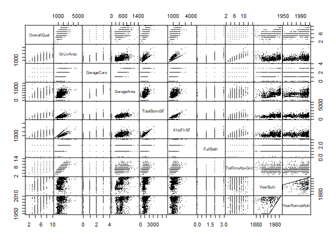

```r
house_important_atts =  house %>% select(c("Id",imp_vars, "SalePrice"))
pairs(house %>% select(c(imp_vars)), gap = 0, pch = ".")
```

```r
#house_important_atts %>% gather(name_attr, value_attr, OverallQual:YearRemodAdd) %>% hchart("s", hcaes(x = value_attr, y = SalePrice, group = name_attr))

#model <- lm(SalePrice ~ OverallQual + GrLivArea + GarageCars + GarageArea + TotalBsmtSF +X1stFlrSF +FullBath + TotRmsAbvGrd + YearBuilt + YearRemodAdd , data = house_important_atts)
#print(ols_vif_tol(model))
```

We can loosely see that there is a linear relation between 5th and 6th (TotalBsmtSF and X1stFlrSF), 5th and 10th (TotalBsmtSF and YearRemodAdd), 6th and 10th (X1stFlrSF and YearRemodAdd), 9th and 10th (YearBuilt and YearRemodAdd), 5th and 9th(TotalBsmtSF and YearBuilt), 6th and 9th(X1stFlrSF and YearBuilt)

```r
model <- lm(SalePrice ~ OverallQual + GrLivArea + GarageCars + GarageArea + TotalBsmtSF +X1stFlrSF +FullBath + TotRmsAbvGrd + YearBuilt + YearRemodAdd , data = house_important_atts)
summary(model)
```

```
##
## Call:
## lm(formula = SalePrice ~ OverallQual + GrLivArea + GarageCars +
##     GarageArea + TotalBsmtSF + X1stFlrSF + FullBath + TotRmsAbvGrd +
##     YearBuilt + YearRemodAdd, data = house_important_atts)
##
## Residuals:
##     Min      1Q  Median      3Q     Max
## -489958  -19316   -1948   16020  290558
##
## Coefficients:
##                Estimate Std. Error t value Pr(>|t|)
## (Intercept)  -1.186e+06  1.291e+05  -9.187  < 2e-16 ***
## OverallQual   1.960e+04  1.190e+03  16.472  < 2e-16 ***
## GrLivArea     5.130e+01  4.233e+00  12.119  < 2e-16 ***
## GarageCars    1.042e+04  3.044e+03   3.422 0.000639 ***
## GarageArea    1.495e+01  1.031e+01   1.450 0.147384
## TotalBsmtSF   1.986e+01  4.295e+00   4.625 4.09e-06 ***
## X1stFlrSF     1.417e+01  4.930e+00   2.875 0.004097 **
## FullBath     -6.791e+03  2.682e+03  -2.532 0.011457 *
## TotRmsAbvGrd  3.310e+01  1.119e+03   0.030 0.976404
## YearBuilt     2.682e+02  5.035e+01   5.328 1.15e-07 ***
## YearRemodAdd  2.965e+02  6.363e+01   4.659 3.47e-06 ***
## ---
## Signif. codes:  0 '***' 0.001 '**' 0.01 '*' 0.05 '.' 0.1 ' ' 1
##
## Residual standard error: 37920 on 1449 degrees of freedom
## Multiple R-squared:  0.7737, Adjusted R-squared:  0.7721
## F-statistic: 495.4 on 10 and 1449 DF,  p-value: < 2.2e-16
```

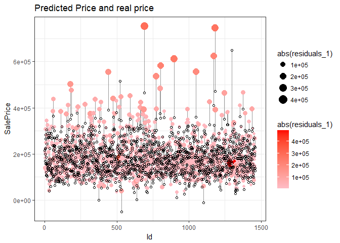

```r
house_important_atts$predicted_1 <- predict(model)
house_important_atts$residuals_1 <- residuals(model)
ggplot(house_important_atts, aes(x = Id, y = SalePrice)) + geom_segment(aes(xend = Id, yend = predicted_1), alpha = 0.4) + geom_point(aes(size = abs(residuals_1), color = abs(residuals_1))) + geom_point(aes(y = predicted_1), shape = 1) + theme_bw()  + scale_color_continuous(low = "pink", high = "red") + ggtitle("Predicted Price and real price")
```

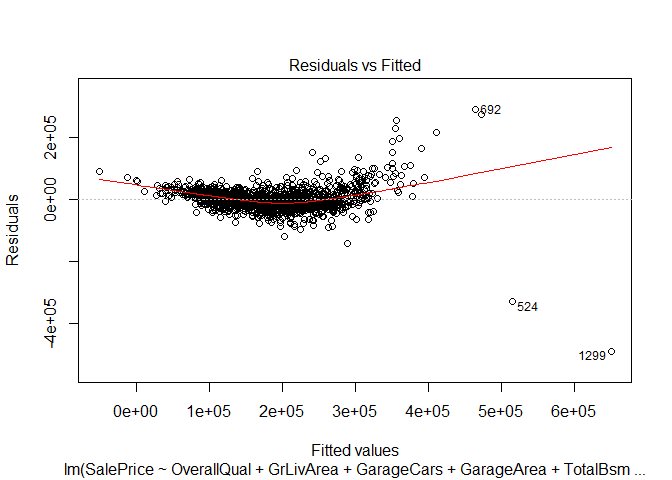

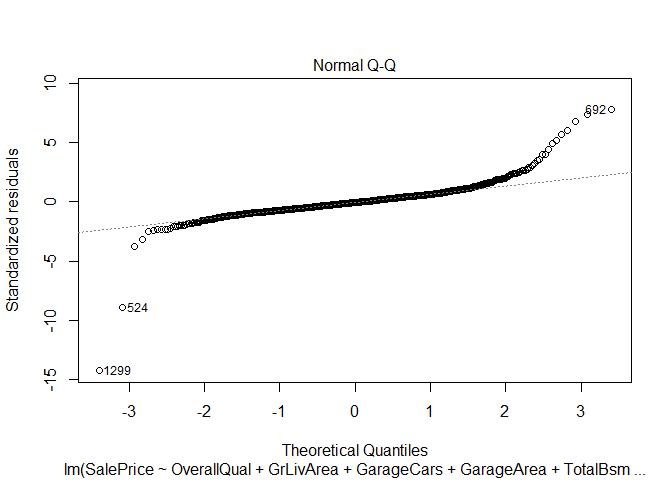

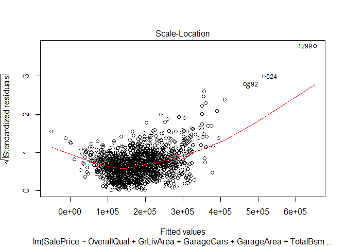

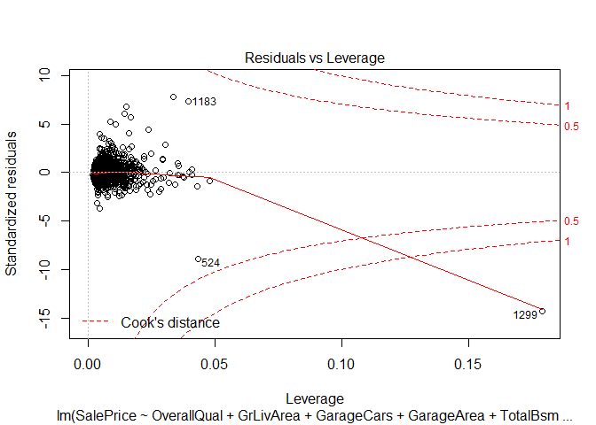

```r
plot(model)
```

Dots are mainly pink and small, meaning they are near their predicted values. So in general we can say our model is good.

```r
summary(model)
```

```
##
## Call:
## lm(formula = SalePrice ~ OverallQual + GrLivArea + GarageCars +
##     GarageArea + TotalBsmtSF + X1stFlrSF + FullBath + TotRmsAbvGrd +
##     YearBuilt + YearRemodAdd, data = house_important_atts)
##
## Residuals:
##     Min      1Q  Median      3Q     Max
## -489958  -19316   -1948   16020  290558
##
## Coefficients:
##                Estimate Std. Error t value Pr(>|t|)
## (Intercept)  -1.186e+06  1.291e+05  -9.187  < 2e-16 ***
## OverallQual   1.960e+04  1.190e+03  16.472  < 2e-16 ***
## GrLivArea     5.130e+01  4.233e+00  12.119  < 2e-16 ***
## GarageCars    1.042e+04  3.044e+03   3.422 0.000639 ***
## GarageArea    1.495e+01  1.031e+01   1.450 0.147384
## TotalBsmtSF   1.986e+01  4.295e+00   4.625 4.09e-06 ***
## X1stFlrSF     1.417e+01  4.930e+00   2.875 0.004097 **
## FullBath     -6.791e+03  2.682e+03  -2.532 0.011457 *
## TotRmsAbvGrd  3.310e+01  1.119e+03   0.030 0.976404
## YearBuilt     2.682e+02  5.035e+01   5.328 1.15e-07 ***
## YearRemodAdd  2.965e+02  6.363e+01   4.659 3.47e-06 ***
## ---
## Signif. codes:  0 '***' 0.001 '**' 0.01 '*' 0.05 '.' 0.1 ' ' 1
##
## Residual standard error: 37920 on 1449 degrees of freedom
## Multiple R-squared:  0.7737, Adjusted R-squared:  0.7721
## F-statistic: 495.4 on 10 and 1449 DF,  p-value: < 2.2e-16
```

```r
print(summary(model)$r.squared)
```

```
## [1] 0.7736928
```

R-squared is 0.7736928. It is a fairly good value (but not a very good one). F-statistic is 495 on 10 and 1449 degrees of freedom. It is a very significant value. This means we can have confidence on the R-squared value. Because high value of R-squared is not because of inherent relations between predictors.

```r
adjusted_model <- lm(SalePrice ~ OverallQual + GrLivArea + GarageCars + TotalBsmtSF +X1stFlrSF + YearBuilt + YearRemodAdd , data = house_important_atts)
summary(adjusted_model)
```

```
##
## Call:
## lm(formula = SalePrice ~ OverallQual + GrLivArea + GarageCars +
##     TotalBsmtSF + X1stFlrSF + YearBuilt + YearRemodAdd, data = house_important_atts)
##
## Residuals:
##     Min      1Q  Median      3Q     Max
## -471221  -19922   -1681   16246  291326
##
## Coefficients:
##                Estimate Std. Error t value Pr(>|t|)
## (Intercept)  -1.075e+06  1.217e+05  -8.833  < 2e-16 ***
## OverallQual   1.949e+04  1.190e+03  16.377  < 2e-16 ***
## GrLivArea     4.768e+01  2.713e+00  17.576  < 2e-16 ***
## GarageCars    1.381e+04  1.820e+03   7.586 5.85e-14 ***
## TotalBsmtSF   2.174e+01  4.249e+00   5.117 3.53e-07 ***
## X1stFlrSF     1.407e+01  4.925e+00   2.856  0.00435 **
## YearBuilt     2.292e+02  4.799e+01   4.777 1.96e-06 ***
## YearRemodAdd  2.768e+02  6.337e+01   4.367 1.35e-05 ***
## ---
## Signif. codes:  0 '***' 0.001 '**' 0.01 '*' 0.05 '.' 0.1 ' ' 1
##
## Residual standard error: 38010 on 1452 degrees of freedom
## Multiple R-squared:  0.7722, Adjusted R-squared:  0.7711
## F-statistic: 703.2 on 7 and 1452 DF,  p-value: < 2.2e-16
```

```r
print(summary(adjusted_model)$r.squared)
```

```
## [1] 0.7722108
```

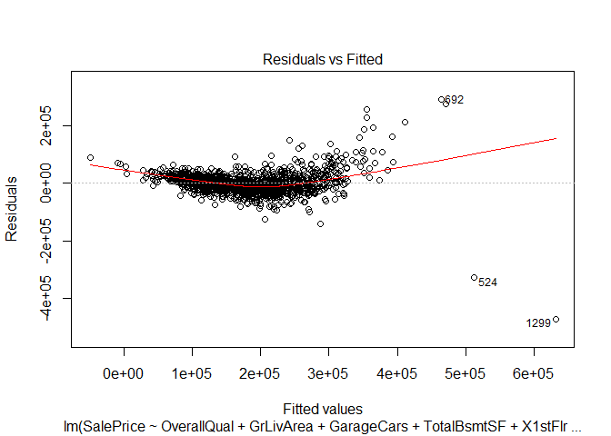

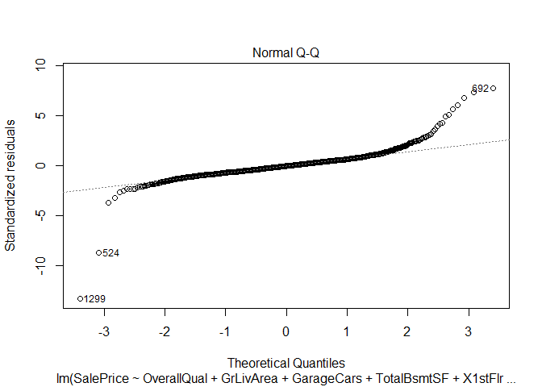

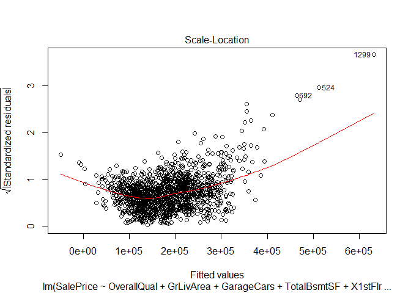

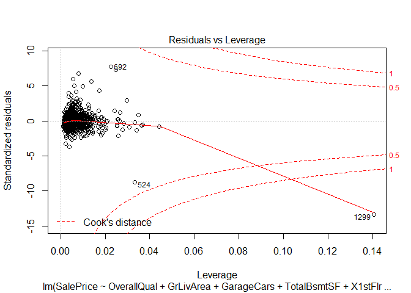

```r
plot(adjusted_model)
```

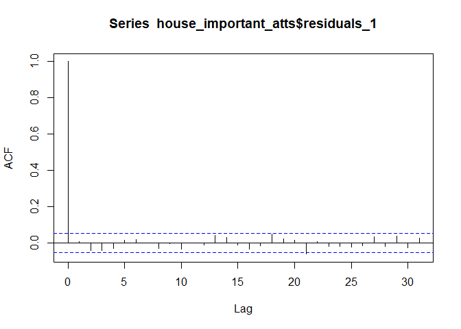

```r
acf(house_important_atts$residuals_1)
```

8. If we have $e = sum (y_i - y'_i)^2$ where $y'$ is predicted price and $y$ is actual price, we will have:

```r
Cross_validation <- cv.lm(data=house_important_atts, form.lm=adjusted_model, m= 5, plotit = F)
```

```
## Analysis of Variance Table
##
## Response: SalePrice
##                Df   Sum Sq  Mean Sq F value  Pr(>F)
## OverallQual     1 5.76e+12 5.76e+12 3988.10 < 2e-16 ***
## GrLivArea       1 8.15e+11 8.15e+11  564.26 < 2e-16 ***
## GarageCars      1 2.29e+11 2.29e+11  158.70 < 2e-16 ***
## TotalBsmtSF     1 1.99e+11 1.99e+11  137.68 < 2e-16 ***
## X1stFlrSF       1 8.13e+09 8.13e+09    5.63   0.018 *
## YearBuilt       1 7.06e+10 7.06e+10   48.87 4.2e-12 ***
## YearRemodAdd    1 2.76e+10 2.76e+10   19.07 1.3e-05 ***
## Residuals    1452 2.10e+12 1.44e+09
## ---
## Signif. codes:  0 '***' 0.001 '**' 0.01 '*' 0.05 '.' 0.1 ' ' 1
##
##
## fold 1
## Observations in test set: 292
##                  4      7      9     11     12     15     19     22     26
## Predicted   198702 263910 190866 117197 309436 151940 156915 139440 270544
## cvpred      200111 263270 189928 115884 310111 150046 157265 140398 270948
## SalePrice   140000 307000 129900 129500 345000 157000 159000 139400 256300
## CV residual -60111  43730 -60028  13616  34889   6954   1735   -998 -14648
##                30     38     45     54     55     68    76     81     83
## Predicted   41432 156856 123345 299482 131438 225296 79479 189612 268194
## cvpred      41074 156439 121512 298583 134474 225096 79655 188841 268530
## SalePrice   68500 153000 141000 385000 130000 226000 91000 193500 245000
## CV residual 27426  -3439  19488  86417  -4474    904 11345   4659 -23530
##                 84     88     93    99    106    111    112    120    131
## Predicted   130560 166204 124006 77419 254832 176435 188283 179671 223698
## cvpred      129584 167858 125861 78340 255173 175761 191346 180795 223590
## SalePrice   126500 164500 163500 83000 250000 136900 180000 163990 226000
## CV residual  -3084  -3358  37639  4660  -5173 -38861 -11346 -16805   2410
##                132    133    137    143    151    153    159    163    164
## Predicted   215250 158088 132736 136218 130136 195092 231482 232050  66157
## cvpred      215206 159392 130984 135017 129939 195228 231817 231601  64221
## SalePrice   244000 150750 143000 166000 122000 190000 254900 220000 103200
## CV residual  28794  -8642  12016  30983  -7939  -5228  23083 -11601  38979
##                166    167    172    175    184    185    197    201    204
## Predicted   110216 186260 186866 211150 250421 122123 262312 137779 154198
```

[output cut: 814 more lines]

```
## Predicted   103164 149002 150617 179695 150198 191236 260386 245226 219639
## cvpred       99541 150532 143274 173938 146541 196046 259958 244823 230887
## SalePrice    91000 117000 167500 157000 112000 124000 282922 175900 223000
## CV residual  -8541 -33532  24226 -16938 -34541 -72046  22964 -68923  -7887
##               1421   1438   1444   1452   1453   1457
## Predicted   158049 299506 113957 270121 142500 234533
## cvpred      154343 306632 113315 271231 134522 241945
## SalePrice   179900 394617 121000 287090 145000 210000
## CV residual  25557  87985   7685  15859  10478 -31945
##
## Sum of squares = 5.94e+11    Mean square = 2.03e+09    n = 292
##
## Overall (Sum over all 292 folds)
##       ms
## 1.51e+09
```

```r
upp = Cross_validation %>% rowwise() %>% mutate(updif = (cvpred-SalePrice)^2, down = SalePrice^2)
error_cross_validation = mean(upp$updif)
error_cross_validation
```

```
## [1] 1.51e+09
```

```r
test_data <- read.csv("test.csv")
ten_data <- predict(model, test_data)
View(ten_data)
write.csv(ten_data, "C:\\Users\\hoco\\Desktop\\data analysis\\hw_06\\ouuuuuuuut.csv")
```

The score is 0.73 (username: alimof)